# `BTYD` Customer Lifetime Value

# Data Acquisition

We will use The Global Superstore dataset that contains information about products, sales, profits, and so on; data that can generate rich information to identify actionable insights or key areas for improvement within this company.

The dataset has information of around 50k orders from 2014 to 2017 made at multiple markets worldwide.

[Click here to access the dataset.](https://community.tableau.com/thread/278494)

Loading **order datasets…**.

Here is a **sample** of the order datasets.

```r
# Reading the dataset

data.order <- data.frame(read_excel("Global Superstore 2018.xlsx", sheet="Orders"))

data.order$Order.Year <- substr(data.order$Order.Date, 1,4)

datatable(data.order[(1:20),], filter = 'top', options = list(
  pageLength = 5, scrollX = TRUE, scrollY = "200px", autoWidth = TRUE), caption = 'Table 1: Orders dataset.')
```

|  | Row.ID | Order.ID | Order.Date | Ship.Date | Ship.Mode | Customer.ID | Customer.Name | Segment | Postal.Code | City | State | Country | Region | Market | Product.ID | Product.Name | Sub.Category | Category | Sales | Quantity | Discount | Profit | Shipping.Cost | Order.Priority | Order.Year |
| --- | --- | --- | --- | --- | --- | --- | --- | --- | --- | --- | --- | --- | --- | --- | --- | --- | --- | --- | --- | --- | --- | --- | --- | --- | --- |
| 1 | 24599 | IN-2017-CA120551-42816 | 2017-03-22T00:00:00Z | 2017-03-29T00:00:00Z | Standard Class | CA-120551 | Cathy Armstrong | Home Office |  | Herat | Hirat | Afghanistan | Southern Asia | Asia Pacific | FUR-BO-4861 | Ikea Library with Doors, Mobile | Bookcases | Furniture | 731.82 | 2 | 0 | 102.42 | 39.66 | Medium | 2017 |
| 2 | 29465 | ID-2015-BD116051-42248 | 2015-09-01T00:00:00Z | 2015-09-04T00:00:00Z | Second Class | BD-116051 | Brian Dahlen | Consumer |  | Herat | Hirat | Afghanistan | Southern Asia | Asia Pacific | OFF-SU-2988 | Acme Scissors, Easy Grip | Supplies | Office Supplies | 243.54 | 9 | 0 | 104.49 | 18.72 | Medium | 2015 |
| 3 | 24598 | IN-2017-CA120551-42816 | 2017-03-22T00:00:00Z | 2017-03-29T00:00:00Z | Standard Class | CA-120551 | Cathy Armstrong | Home Office |  | Herat | Hirat | Afghanistan | Southern Asia | Asia Pacific | TEC-MA-4211 | Epson Receipt Printer, White | Machines | Technology | 346.32 | 3 | 0 | 13.77 | 14.1 | Medium | 2017 |
| 4 | 24597 | IN-2017-CA120551-42816 | 2017-03-22T00:00:00Z | 2017-03-29T00:00:00Z | Standard Class | CA-120551 | Cathy Armstrong | Home Office |  | Herat | Hirat | Afghanistan | Southern Asia | Asia Pacific | FUR-FU-5726 | Rubbermaid Door Stop, Erganomic | Furnishings | Furniture | 169.68 | 4 | 0 | 79.68 | 11.01 | Medium | 2017 |
| 5 | 29464 | ID-2015-BD116051-42248 | 2015-09-01T00:00:00Z | 2015-09-04T00:00:00Z | Second Class | BD-116051 | Brian Dahlen | Consumer |  | Herat | Hirat | Afghanistan | Southern Asia | Asia Pacific | OFF-EN-3664 | Cameo Interoffice Envelope, with clear poly window | Envelopes | Office Supplies | 203.88 | 4 | 0 | 24.36 | 5.72 | Medium | 2015 |
| 6 | 28879 | ID-2015-AJ107801-42113 | 2015-04-19T00:00:00Z | 2015-04-22T00:00:00Z | First Class | AJ-107801 | Anthony Jacobs | Corporate |  | Kabul | Kabul | Afghanistan | Southern Asia | Asia Pacific | FUR-TA-3420 | Bevis Conference Table, Fully Assembled | Tables | Furniture | 4626.15 | 5 | 0 | 647.55 | 835.57 | High | 2015 |
| 7 | 27993 | IN-2017-GM144551-42948 | 2017-08-01T00:00:00Z | 2017-08-05T00:00:00Z | Standard Class | GM-144551 | Gary Mitchum | Home Office |  | Kabul | Kabul | Afghanistan | Southern Asia | Asia Pacific | FUR-BO-3626 | Bush Classic Bookcase, Pine | Bookcases | Furniture | 2070.15 | 5 | 0 | 848.7 | 185.01 | Medium | 2017 |
| 8 | 28967 | IN-2017-VB217451-43080 | 2017-12-11T00:00:00Z | 2017-12-15T00:00:00Z | Standard Class | VB-217451 | Victoria Brennan | Corporate |  | Kabul | Kabul | Afghanistan | Southern Asia | Asia Pacific | FUR-CH-4683 | Hon Rocking Chair, Red | Chairs | Furniture | 914.34 | 7 | 0 | 356.58 | 106.41 | High | 2017 |
| 9 | 29492 | IN-2016-LO171701-42637 | 2016-09-24T00:00:00Z | 2016-09-28T00:00:00Z | Standard Class | LO-171701 | Lori Olson | Corporate |  | Kabul | Kabul | Afghanistan | Southern Asia | Asia Pacific | TEC-PH-5814 | Samsung Audio Dock, VoIP | Phones | Technology | 1168.44 | 7 | 0 | 443.94 | 92.34 | Medium | 2016 |
| 10 | 28966 | IN-2017-VB217451-43080 | 2017-12-11T00:00:00Z | 2017-12-15T00:00:00Z | Standard Class | VB-217451 | Victoria Brennan | Corporate |  | Kabul | Kabul | Afghanistan | Southern Asia | Asia Pacific | TEC-PH-3129 | Apple Audio Dock, VoIP | Phones | Technology | 500.94 | 3 | 0 | 115.2 | 79.59 | High | 2017 |

[output cut: 10 more lines]

Checking **missing values…**

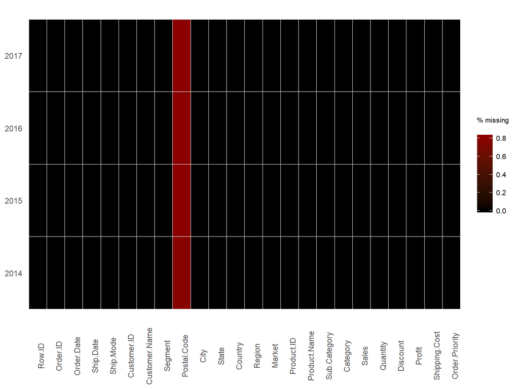

Missing Values Review

```r
prepare_missing_values_graph(data.order, ts_id = "Order.Year") + scale_fill_gradient(low="black", high="darkred")
```

We can notice that only **Postal Code** has **missing values**. So no big issues with the data since we need mainly the columns: order date, customer id, and sales. These columns will be the pillars for our CLV model.

# Data Preparation

As next step, we will group the data (order lines) and put the transaction date in a correct format. Then, we will present a complete transaction records of 30 customers.

```
[1] "2014-01-01" "2017-12-31"
```

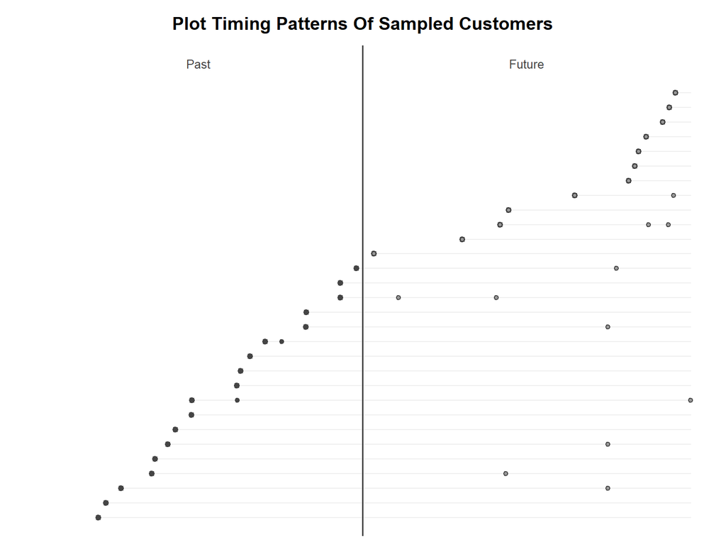

# Data Modeling

We will implement a BG/NBD model that is used for non-contractual situations in which customers can make purchases at any time.

[Click here to access the research paper.](http://brucehardie.com/papers/018/fader_et_al_mksc_05.pdf)

```r
print('Checking a sample of the final data structure.')
```

```
[1] "Checking a sample of the final data structure."
```

```r
elog$date <- as.Date(elog$date, "%Y%m%d");

elog[1:3,]
```

```
# A tibble: 3 x 3
  cust       date       sales
  <chr>      <date>     <dbl>
1 PO-8865138 2014-10-02 161.
2 EB-4110138 2016-10-14 229.
3 MY-7380138 2016-12-31  23.6
```

Merging all transactions that occurred on the **same day.** Transaction-flow models, such as the BG/NBD, is concerned with interpurchase time.

Dividing the data up into a calibration period and a holdout period. We will use **December 31, 2015** as the cutoff date, so 104 weeks are dividing the dataset in half.

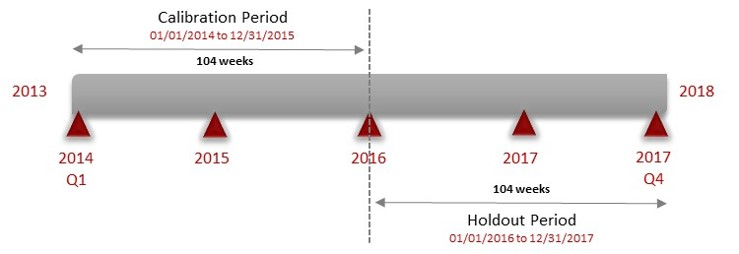

```r
end.of.cal.period <- as.Date("2015-12-31")
elog.cal <- elog[which(elog$date <= end.of.cal.period), ]

split.data <- dc.SplitUpElogForRepeatTrans(elog.cal);
clean.elog <- split.data$repeat.trans.elog;
```

The next step is to create a **customer-by-time matrix**. This is simply a matrix with a row for each customer and a column for each date.

```
              date
cust           2014-01-27 2014-02-18 2014-03-07 2014-03-22 2014-04-01
  DB-135551408          0          0          0          0          0
  DL-133151402          0          1          0          0          0
  Dl-136001404          0          0          0          0          0
  DN-136901406          0          0          0          0          0
  DP-130001402          0          0          0          0          0
              date
cust           2014-04-02
  DB-135551408          0
  DL-133151402          0
  Dl-136001404          0
  DN-136901406          0
  DP-130001402          0
```

```
[1] 1.606620e+00 3.955141e+02 4.579787e-03 5.676831e+02
```

```
[1] -10586.29
```

```
         r    alpha           a        b        LL
1 1.606620 395.5141 0.004579787 567.6831 -10586.29
2 1.606584 395.5266 0.004579787 567.6832 -10586.29
3 1.606617 395.5282 0.004579786 567.6833 -10586.29
```

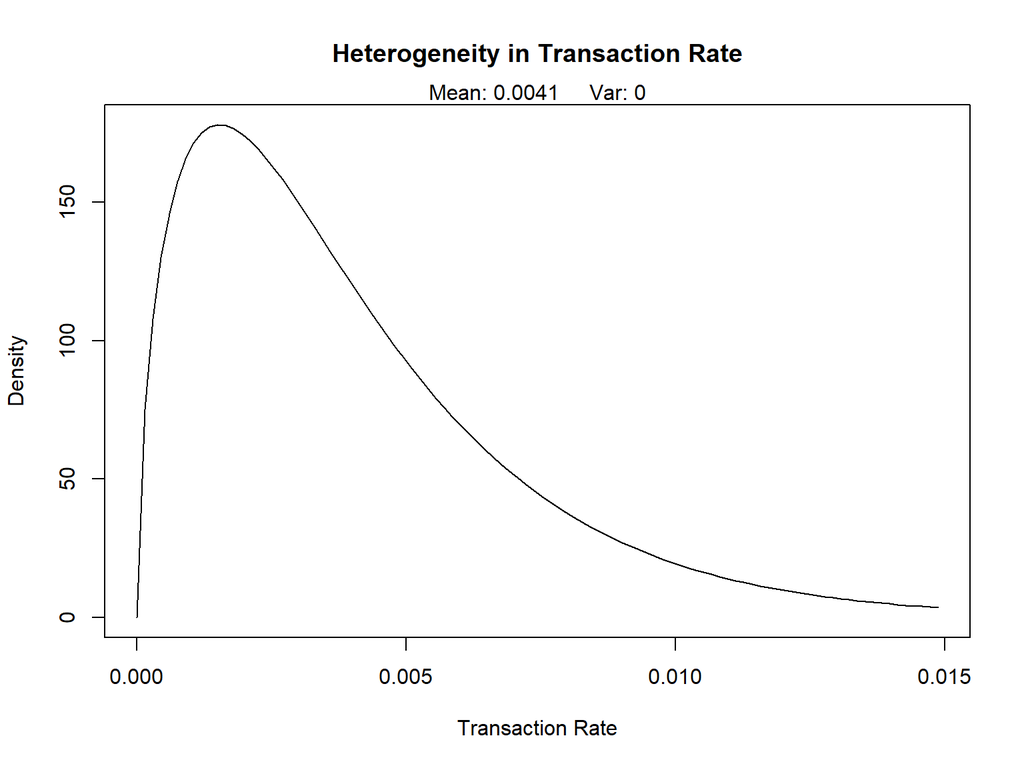

[output not shown]

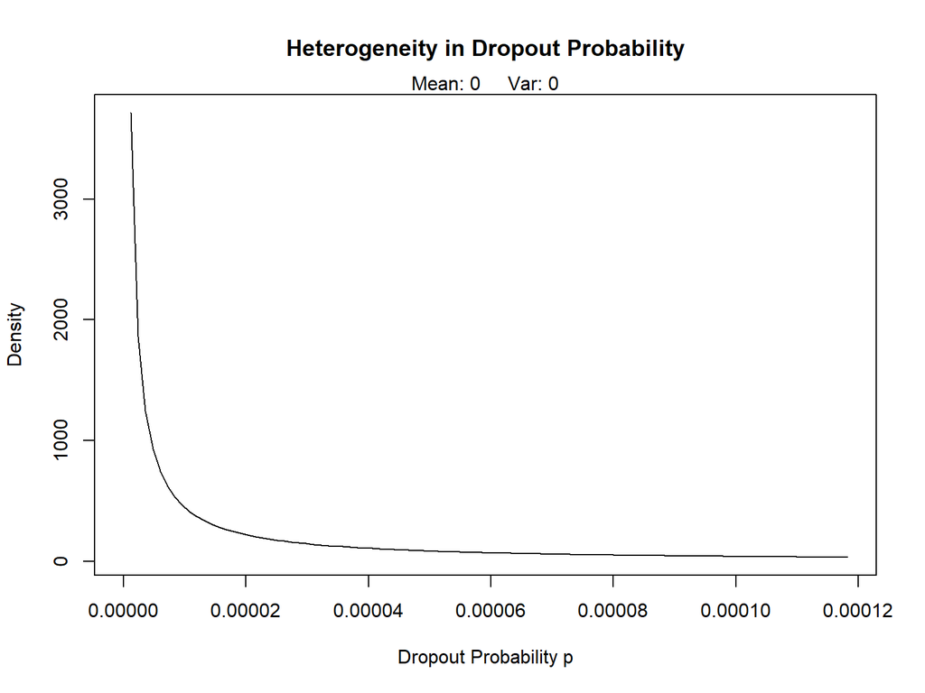

[output not shown]

# Evaluation

Making estimations for customers on the individual level.

```
[1] "Customer: AA-10315102"
```

```
[1] 0.2112213
```

```
    x   t.x T.cal
    0     0    78
```

```
[1] 0.1764288
```

```
[1] 1
```

```
x: 10    Expectation: 1.388937
x: 15    Expectation: 1.987265
x: 20    Expectation: 2.585584
x: 25    Expectation: 3.183893
```

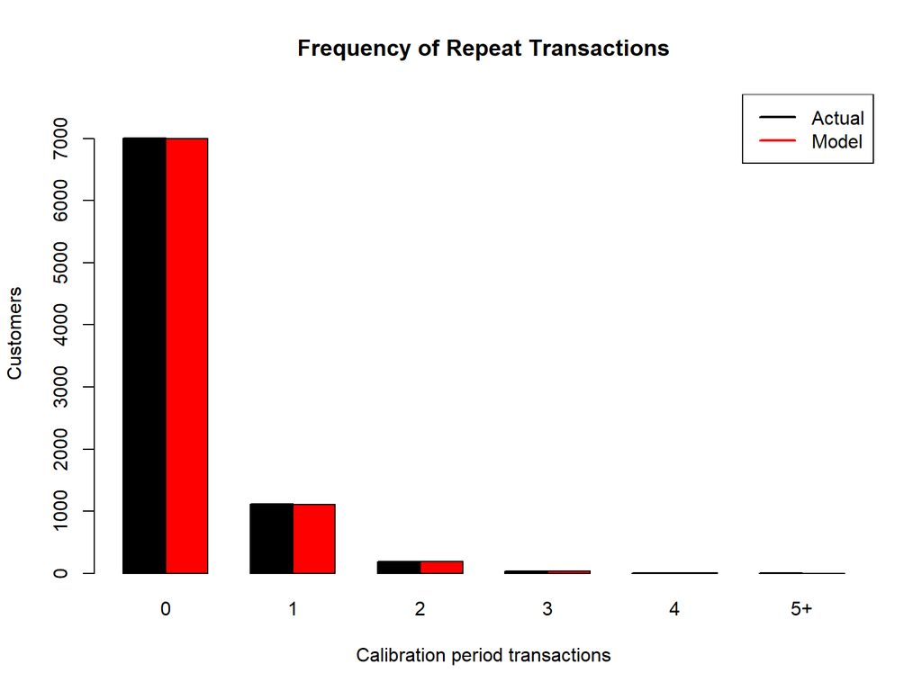

```
               freq.0   freq.1   freq.2   freq.3   freq.4  freq.5+
n.x.actual   7010.000 1120.000 190.0000 35.00000 4.000000 2.000000
n.x.expected 6998.128 1106.972 194.2761 35.46713 6.610739 1.249961
```

```
           x t.x     T.cal x.star
PO-8865138 0   0  65.00000      0
AA-6453    0   0  88.42857      0
AC-4203    0   0 103.28571      1
```

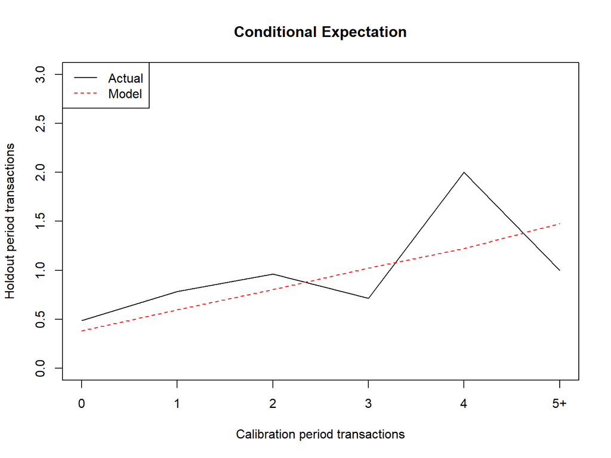

```
          freq.0       freq.1      freq.2     freq.3   freq.4  freq.5+
act    0.4888730    0.7812500   0.9631579  0.7142857 2.000000 1.000000
exp    0.3807435    0.5951219   0.8043287  1.0232692 1.219812 1.478683
bin 7010.0000000 1120.0000000 190.0000000 35.0000000 4.000000 2.000000
```

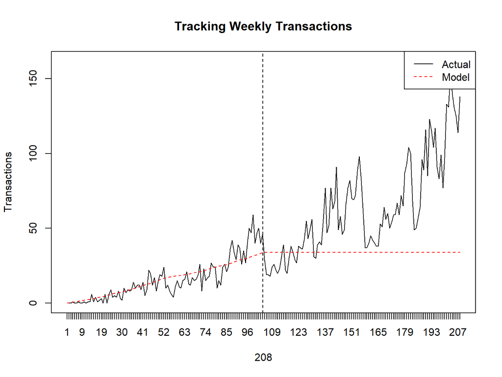

```
             [,1]     [,2]     [,3]     [,4]    [,5]     [,6]
actual   0.000000 6.000000 0.000000 6.000000 9.00000 4.000000
expected 4.467566 4.712444 5.005485 5.466226 5.84979 6.256565
```

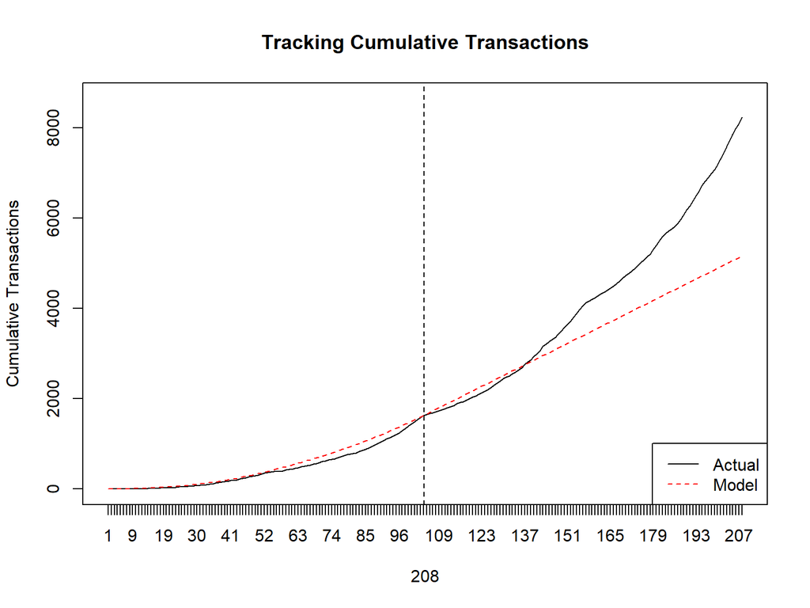

```
             [,1]     [,2]    [,3]     [,4]     [,5]     [,6]
actual   22.00000 28.00000 28.0000 34.00000 43.00000 47.00000
expected 42.96617 47.67861 52.6841 58.15032 64.00011 70.25668
```

Saul Ventura

Last update: 21 February, 2019